## Winter 2018

## Data source: World Bank LSMS Tanzania - National Panel Survey 2014-2015

## Downloadable at the World Bank website : http://microdata.worldbank.org/index.php/catalog/2862

### PART 1. BRING IN DATA

Bring in first data set - Tanzania household consumption. The data is in an excel sheet, so we first create a tempfile.

```r
library(readxl)
temp = tempfile(fileext = ".xlsx")
dataURL <- "https://github.com/ihsun-uw/Assignment-1/raw/master/consumptionnps4.xlsx" # link to data
download.file(dataURL, destfile=temp, mode='wb')  # file will be downloaded temporarily
```

Use tempfile to create a data frame

```r
cons = read_excel(temp, sheet =1)
cons=as.data.frame(cons)
```

Bring in the second data set that contains information on the education level of individuals in te household.

Follow the same process as above. First, create tempfile. Second, create data frame.

```r
temp = tempfile(fileext = ".xlsx")
dataURL <- "https://github.com/ihsun-uw/Assignment-1/raw/master/Education.xlsx" # link to data
download.file(dataURL, destfile=temp, mode='wb')  # file will be downloaded temporarily

educ = read_excel(temp, sheet =1)
educ=as.data.frame(educ)
```

Bring in third data set, which has information on the gender of each individual in the household.

Repeat same process as above.

```r
temp = tempfile(fileext = ".xlsx")
dataURL <- "https://github.com/ihsun-uw/Assignment-1/raw/master/individual.xlsx" # link to data
download.file(dataURL, destfile=temp, mode='wb')  # file will be downloaded temporarily

indiv = read_excel(temp, sheet =1)
indiv=as.data.frame(indiv)
```

### PART 2. MERGING DATA

Now, we need to take the relevant information from each data frame and combine them into one data frame. We’ll exclude the unnecessary variables for simplicity.

To find the relevant variables, first look at names of variables in consumption data

```r
names(cons)
```

Keep the household ID variable to match observations from other data frames, real consumption, the number of adult equivalents in the household, and region.

Re-save data frame with only necessary variables from consumption data.

```r
cons=cons[,c("y4_hhid", "expmR", "adulteq", "region")]
```

Repeat process for education data frame. Look at names of variables in education data

```r
names(educ)
```

Keep household id, individual id, whether the individual can read/write, whether the individual has ever gone to school, what is the highest grade achieved by the individual.

Saving data frame with only necessary variables from education data

```r
educ=educ[,c("y4_hhid", "indidy4", "hh_c02", "hh_c03", "hh_c07")]
```

Repeat process again for individual data frame. Looking at names of variables in characteristics data

```r
names(indiv)
```

Keep variables for household id, individual id, and gender of each individual in the hh.

Saving individual data frame with only the relevant variables

```r
indiv=indiv[,c("y4_hhid", "indidy4", "hh_b02")]
```

The data frames will not match up because the consumption information is at the household level but the individual and education information is at the individual level.

For now, we only want the information on the head of household which has the individual id = 1.

Collapsing education data frame to only include heads of household

```r
educ=educ[educ$indidy4==1,]
```

Collapsing individual characteristics data frame to only include head of household so we can merge

```r
indiv=indiv[indiv$indidy4==1,]
```

Merge data by household ID.

```r
merge1=merge(cons, educ)

alldata=merge(merge1, indiv)
```

Let’s look at our merged data…

```r
str(alldata)
```

```
## 'data.frame':    3344 obs. of  9 variables:
##  $ y4_hhid: chr  "1000-001" "1001-001" "1002-001" "1003-001" ...
##  $ indidy4: num  1 1 1 1 1 1 1 1 1 1 ...
##  $ expmR  : num  5258470 3069467 2059339 1902953 3575687 ...
##  $ adulteq: num  5.64 5.92 2.48 2.96 2.92 ...
##  $ region : num  2 2 2 2 2 2 2 2 2 2 ...
##  $ hh_c02 : num  1 1 1 5 1 1 1 1 1 3 ...
##  $ hh_c03 : num  1 1 1 2 1 1 1 1 1 1 ...
##  $ hh_c07 : num  14 17 14 NA 17 17 17 17 17 24 ...
##  $ hh_b02 : num  1 1 1 2 1 1 1 1 2 1 ...
```

### PART 3. CLEAN AND EXPLORE THE DATA

Now we want to explore our chosen variables to determine what they are telling us. In order to explore some variables, we will need to do a bit of cleaning so that it is more meaningful and comparable.

#### Section 3.1 UNIVARTIATE ANALYSIS

Start with univariate analysis and examine the variables on their own.

Create new variable for consumption per household equivalent (consumption per capita)

```r
alldata$cons=alldata$expmR/alldata$adulteq/365
```

Now we can explore consumption per capita

Summary statistics (min, max, quartiles, mean)

```r
summary(alldata$cons)
```

```
##    Min. 1st Qu.  Median    Mean 3rd Qu.    Max.
##   135.2  1687.1  2736.1  3511.8  4371.9 37266.2
```

standard deviation

```r
sd(alldata$cons,na.rm = T)
```

```
## [1] 2842.011
```

Create histogram and show mean and median like its a normal curve.

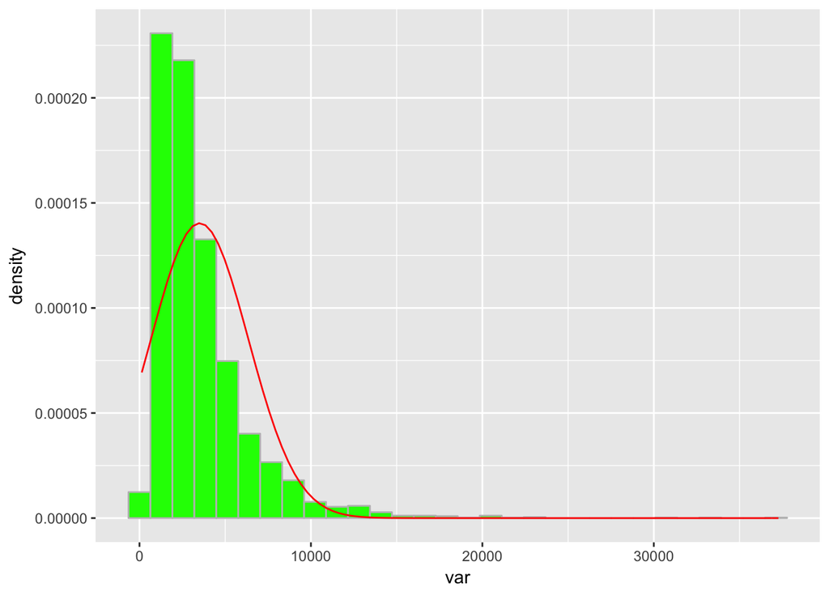

```r
data=alldata[is.finite(alldata$'cons'),]

var=alldata$'cons'

mnVar=mean(var,na.rm = T)
sdVar=sd(var,na.rm = T)

library(ggplot2)

base = ggplot(data, aes(x=var))
hist = base + geom_histogram(fill="green",
                             color='grey',
                          aes(y=..density..))


histAndNormal = hist + stat_function(fun=dnorm,
                                     color="red",
                                     args=list(mean=mnVar,sd=sdVar))

histAndNormal
```

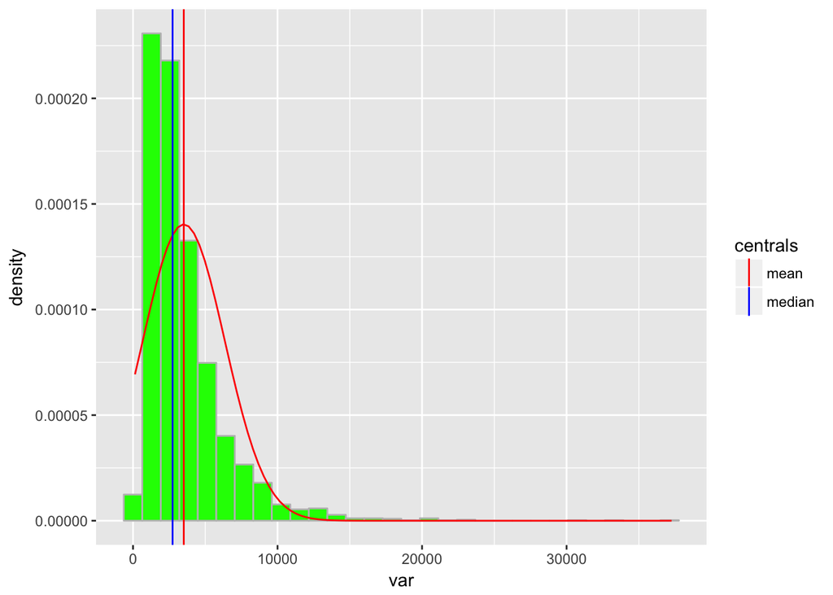

```r
mdVar=median(var)

histAndNormal + geom_vline(aes(xintercept = mnVar,colour="mean"),
                           show.legend  = TRUE) +
                geom_vline(aes(xintercept = mdVar,colour="median"),
                           show.legend  = TRUE) +
                scale_color_manual(name = "centrals",
                                   values = c(median = "blue", mean = "red"))
```

#### Clean data- Gender of head of household

recode variables 1=male 2=female keep numerical and change to 0 and 1 so we can calculate the proportion of female headed households when we aggregate at the region level.

```r
alldata$gender.name[alldata$hh_b02==1] <- "male"
alldata$gender.name[alldata$hh_b02==2] <- "female"

alldata$gender[alldata$hh_b02==1] <- 0
alldata$gender[alldata$hh_b02==2] <- 1
```

Check variable type

```r
str(alldata)
```

```
## 'data.frame':    3344 obs. of  12 variables:
##  $ y4_hhid    : chr  "1000-001" "1001-001" "1002-001" "1003-001" ...
##  $ indidy4    : num  1 1 1 1 1 1 1 1 1 1 ...
##  $ expmR      : num  5258470 3069467 2059339 1902953 3575687 ...
##  $ adulteq    : num  5.64 5.92 2.48 2.96 2.92 ...
##  $ region     : num  2 2 2 2 2 2 2 2 2 2 ...
##  $ hh_c02     : num  1 1 1 5 1 1 1 1 1 3 ...
##  $ hh_c03     : num  1 1 1 2 1 1 1 1 1 1 ...
##  $ hh_c07     : num  14 17 14 NA 17 17 17 17 17 24 ...
##  $ hh_b02     : num  1 1 1 2 1 1 1 1 2 1 ...
##  $ cons       : num  2554 1421 2275 1761 3355 ...
##  $ gender.name: chr  "male" "male" "male" "female" ...
##  $ gender     : chr  "0" "0" "0" "1" ...
```

Gender is showing up as chr instead of num. Gender needs to be a numeric so we can calcualte proportion.

```r
alldata$gender=as.numeric(alldata$gender)
```

Check variable type

```r
str(alldata)
```

```
## 'data.frame':    3344 obs. of  12 variables:
##  $ y4_hhid    : chr  "1000-001" "1001-001" "1002-001" "1003-001" ...
##  $ indidy4    : num  1 1 1 1 1 1 1 1 1 1 ...
##  $ expmR      : num  5258470 3069467 2059339 1902953 3575687 ...
##  $ adulteq    : num  5.64 5.92 2.48 2.96 2.92 ...
##  $ region     : num  2 2 2 2 2 2 2 2 2 2 ...
##  $ hh_c02     : num  1 1 1 5 1 1 1 1 1 3 ...
##  $ hh_c03     : num  1 1 1 2 1 1 1 1 1 1 ...
##  $ hh_c07     : num  14 17 14 NA 17 17 17 17 17 24 ...
##  $ hh_b02     : num  1 1 1 2 1 1 1 1 2 1 ...
##  $ cons       : num  2554 1421 2275 1761 3355 ...
##  $ gender.name: chr  "male" "male" "male" "female" ...
##  $ gender     : num  0 0 0 1 0 0 0 0 1 0 ...
```

#### Clean data - education of head of household

We have a lot of different ways to examine education, so we need to clean a lot of different ways.

recode education with information from multiple questions. 0 if they have never been to school (question hh_c03). Recode categories for other levels of education.

```r
alldata$educ[alldata$hh_c03==2] <- 0
alldata$educ[alldata$hh_c07<17] <- 1
alldata$educ[alldata$hh_c07==17] <-2  #typical primary education is 7 years
alldata$educ[alldata$hh_c07==18] <-2
alldata$educ[alldata$hh_c07>=21 & alldata$hh_c07<25] <- 3
alldata$educ[alldata$hh_c07==24] <-4
alldata$educ[alldata$hh_c07>=31 & alldata$hh_c07<34] <- 5
alldata$educ[alldata$hh_c07==32] <-6
alldata$educ[alldata$hh_c07==34] <-6
alldata$educ[alldata$hh_c07>34] <- 7
```

Check variable type

```r
str(alldata)
```

```
## 'data.frame':    3344 obs. of  13 variables:
##  $ y4_hhid    : chr  "1000-001" "1001-001" "1002-001" "1003-001" ...
##  $ indidy4    : num  1 1 1 1 1 1 1 1 1 1 ...
##  $ expmR      : num  5258470 3069467 2059339 1902953 3575687 ...
##  $ adulteq    : num  5.64 5.92 2.48 2.96 2.92 ...
##  $ region     : num  2 2 2 2 2 2 2 2 2 2 ...
##  $ hh_c02     : num  1 1 1 5 1 1 1 1 1 3 ...
##  $ hh_c03     : num  1 1 1 2 1 1 1 1 1 1 ...
##  $ hh_c07     : num  14 17 14 NA 17 17 17 17 17 24 ...
##  $ hh_b02     : num  1 1 1 2 1 1 1 1 2 1 ...
##  $ cons       : num  2554 1421 2275 1761 3355 ...
##  $ gender.name: chr  "male" "male" "male" "female" ...
##  $ gender     : num  0 0 0 1 0 0 0 0 1 0 ...
##  $ educ       : num  1 2 1 0 2 2 2 2 2 4 ...
```

Create variable with the recoded education level with names instead of numbers.

```r
alldata$educ1[alldata$educ=="0"] <- "no education"
alldata$educ1[alldata$educ=="1"] <- "some primary"
alldata$educ1[alldata$educ=="2"] <- "completed primary"
alldata$educ1[alldata$educ=="3"] <- "some secondary ordinary level"
alldata$educ1[alldata$educ=="4"] <- "completed secondary ordinary level"
alldata$educ1[alldata$educ=="5"] <- "some secondary advanced level"
alldata$educ1[alldata$educ=="6"] <- "completed secondary advanced level"
alldata$educ1[alldata$educ=="7"] <- "some higher education"
```

Check variable type

```r
str(alldata)
```

```
## 'data.frame':    3344 obs. of  14 variables:
##  $ y4_hhid    : chr  "1000-001" "1001-001" "1002-001" "1003-001" ...
##  $ indidy4    : num  1 1 1 1 1 1 1 1 1 1 ...
##  $ expmR      : num  5258470 3069467 2059339 1902953 3575687 ...
##  $ adulteq    : num  5.64 5.92 2.48 2.96 2.92 ...
##  $ region     : num  2 2 2 2 2 2 2 2 2 2 ...
##  $ hh_c02     : num  1 1 1 5 1 1 1 1 1 3 ...
##  $ hh_c03     : num  1 1 1 2 1 1 1 1 1 1 ...
##  $ hh_c07     : num  14 17 14 NA 17 17 17 17 17 24 ...
##  $ hh_b02     : num  1 1 1 2 1 1 1 1 2 1 ...
##  $ cons       : num  2554 1421 2275 1761 3355 ...
##  $ gender.name: chr  "male" "male" "male" "female" ...
##  $ gender     : num  0 0 0 1 0 0 0 0 1 0 ...
##  $ educ       : num  1 2 1 0 2 2 2 2 2 4 ...
##  $ educ1      : chr  "some primary" "completed primary" "some primary" "no education" ...
```

Reorder education label because we want it to be an ordincal categorical variable.

```r
levelCat=c("no education", "some primary", "completed primary", "some secondary ordinary level", "completed secondary orginary level", "some secondary advanced level", "completed secondary advanced level", "some higher education" )


levelCat
```

```
## [1] "no education"
## [2] "some primary"
## [3] "completed primary"
## [4] "some secondary ordinary level"
## [5] "completed secondary orginary level"
## [6] "some secondary advanced level"
## [7] "completed secondary advanced level"
## [8] "some higher education"
```

Make the variable an ordinal categorical variable

```r
alldata$educ1=factor(alldata$educ1,
                             levels = levelCat,
                             labels=levelCat,ordered=T)

str(alldata)
```

```
## 'data.frame':    3344 obs. of  14 variables:
##  $ y4_hhid    : chr  "1000-001" "1001-001" "1002-001" "1003-001" ...
##  $ indidy4    : num  1 1 1 1 1 1 1 1 1 1 ...
##  $ expmR      : num  5258470 3069467 2059339 1902953 3575687 ...
##  $ adulteq    : num  5.64 5.92 2.48 2.96 2.92 ...
##  $ region     : num  2 2 2 2 2 2 2 2 2 2 ...
##  $ hh_c02     : num  1 1 1 5 1 1 1 1 1 3 ...
##  $ hh_c03     : num  1 1 1 2 1 1 1 1 1 1 ...
##  $ hh_c07     : num  14 17 14 NA 17 17 17 17 17 24 ...
##  $ hh_b02     : num  1 1 1 2 1 1 1 1 2 1 ...
##  $ cons       : num  2554 1421 2275 1761 3355 ...
##  $ gender.name: chr  "male" "male" "male" "female" ...
##  $ gender     : num  0 0 0 1 0 0 0 0 1 0 ...
##  $ educ       : num  1 2 1 0 2 2 2 2 2 4 ...
##  $ educ1      : Ord.factor w/ 8 levels "no education"<..: 2 3 2 1 3 3 3 3 3 NA ...
```

Create variable for whether or not the head of household is literate (can read and write) in any language

```r
alldata$literacy[alldata$hh_c03==1] <- 1
alldata$literacy[alldata$hh_c03==2] <- 1
alldata$literacy[alldata$hh_c03==3] <- 1
alldata$literacy[alldata$hh_c03==4] <- 1
alldata$literacy[alldata$hh_c03==5] <- 0

str(alldata$literacy)
```

```
##  num [1:3344] 1 1 1 1 1 1 1 1 1 1 ...
```

Create a categorical variable for whether household heads completed and did not complete a secondary level education. One variable is numerical so we can get a proportion when we aggregate at the region level. Second variable has the labels

```r
alldata$educ2[alldata$educ<4] <- 0
alldata$educ2[alldata$educ>=4] <-1

alldata$educ3[alldata$educ2==0] <- "Did not complete secondary"
alldata$educ3[alldata$educ2==1] <- "Completed secondary"

str(alldata)
```

```
## 'data.frame':    3344 obs. of  17 variables:
##  $ y4_hhid    : chr  "1000-001" "1001-001" "1002-001" "1003-001" ...
##  $ indidy4    : num  1 1 1 1 1 1 1 1 1 1 ...
##  $ expmR      : num  5258470 3069467 2059339 1902953 3575687 ...
##  $ adulteq    : num  5.64 5.92 2.48 2.96 2.92 ...
##  $ region     : num  2 2 2 2 2 2 2 2 2 2 ...
##  $ hh_c02     : num  1 1 1 5 1 1 1 1 1 3 ...
##  $ hh_c03     : num  1 1 1 2 1 1 1 1 1 1 ...
##  $ hh_c07     : num  14 17 14 NA 17 17 17 17 17 24 ...
##  $ hh_b02     : num  1 1 1 2 1 1 1 1 2 1 ...
##  $ cons       : num  2554 1421 2275 1761 3355 ...
##  $ gender.name: chr  "male" "male" "male" "female" ...
##  $ gender     : num  0 0 0 1 0 0 0 0 1 0 ...
##  $ educ       : num  1 2 1 0 2 2 2 2 2 4 ...
##  $ educ1      : Ord.factor w/ 8 levels "no education"<..: 2 3 2 1 3 3 3 3 3 NA ...
##  $ literacy   : num  1 1 1 1 1 1 1 1 1 1 ...
##  $ educ2      : num  0 0 0 0 0 0 0 0 0 1 ...
##  $ educ3      : chr  "Did not complete secondary" "Did not complete secondary" "Did not complete secondary" "Did not complete secondary" ...
```

#### Explore our other variables

#### Gender

look at distrubution of gender of head of household

```r
table(alldata$gender.name)
```

```
##
## female   male
##    955   2389
```

```r
mean(alldata$gender)
```

```
## [1] 0.2855861
```

#### Education

examine education variable

```r
summary(alldata$educ)
```

```
##    Min. 1st Qu.  Median    Mean 3rd Qu.    Max.    NA's
##   0.000   1.000   2.000   1.726   2.000   7.000     229
```

```r
table(alldata$educ1)
```

```
##
##                       no education                       some primary
##                                724                                544
##                  completed primary      some secondary ordinary level
##                               1302                                206
## completed secondary orginary level      some secondary advanced level
##                                  0                                 19
## completed secondary advanced level              some higher education
##                                 40                                 52
```

Summary statistics for household head literacy

```r
summary(alldata$literacy)
```

```
##    Min. 1st Qu.  Median    Mean 3rd Qu.    Max.    NA's
##       1       1       1       1       1       1       3
```

```r
table(alldata$literacy)
```

```
##
##    1
## 3341
```

Looks like all heads of household are literate in some language. Not going to give us anything interesting

Summary statistics for completing secondary level education

```r
summary(alldata$educ2)
```

```
##    Min. 1st Qu.  Median    Mean 3rd Qu.    Max.    NA's
##  0.0000  0.0000  0.0000  0.1088  0.0000  1.0000     229
```

```r
table(alldata$educ3)
```

```
##
##        Completed secondary Did not complete secondary
##                        339                       2776
```

#### Section 3.2 Bivariate Analysis

#### Bivariate analysis gender and household consumption

Create a boxplot of gender and consumption. Is there a difference?

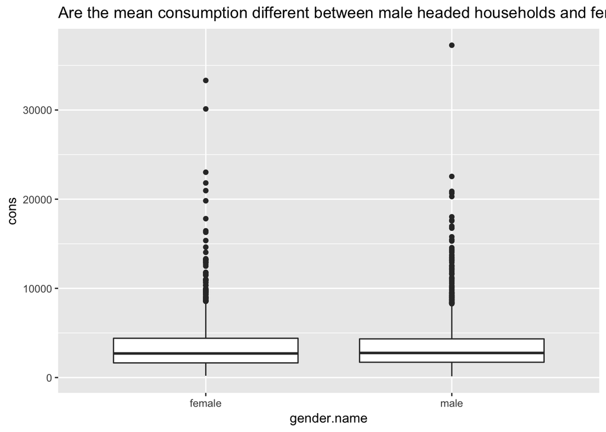

```r
library(ggplot2)

indiv = alldata[alldata$indidy4==1,]
p <- ggplot(indiv, aes(gender.name, cons))

p + geom_boxplot() + labs(title="Are the mean consumption different between male headed households and female headed households?")
```

#### Bivariate analysis of education and consumption

Boxplots of consumption by education level

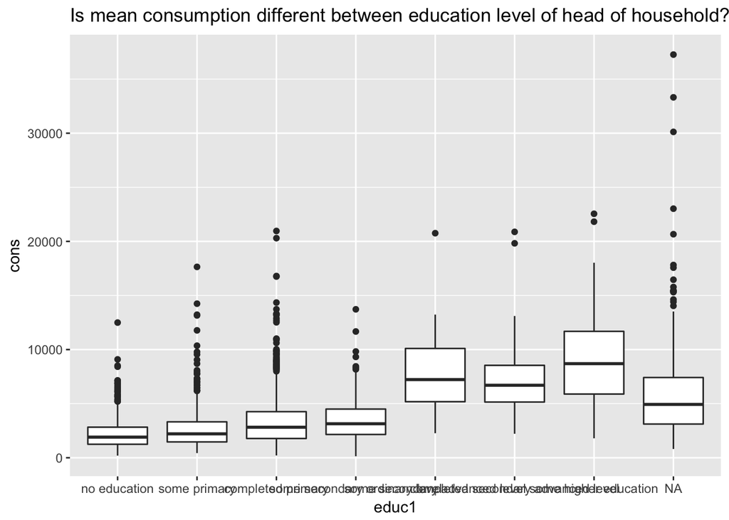

```r
seMean = function(x) sd(x)/sqrt(length(x))

# Means by group
means=aggregate(list(mean=alldata$expmR),
          list(educ=alldata$educ1),mean)

# se by group
sems=aggregate(list(seMean=alldata$expmR),
          list(educ=alldata$educ1),seMean)

# a new data frame:
data=merge(means,sems)

# adding confidence interval limits:
data$lower=data$mean-2*data$seMean
data$upper=data$mean+2*data$seMean


indiv = alldata[alldata$indidy4==1,]
p <- ggplot(indiv, aes(educ1, cons))

p + geom_boxplot() + labs(title="Is mean consumption different between education level of head of household?")
```

Create boxplots of consumption by whether or not the head of household has completed a secondary level education

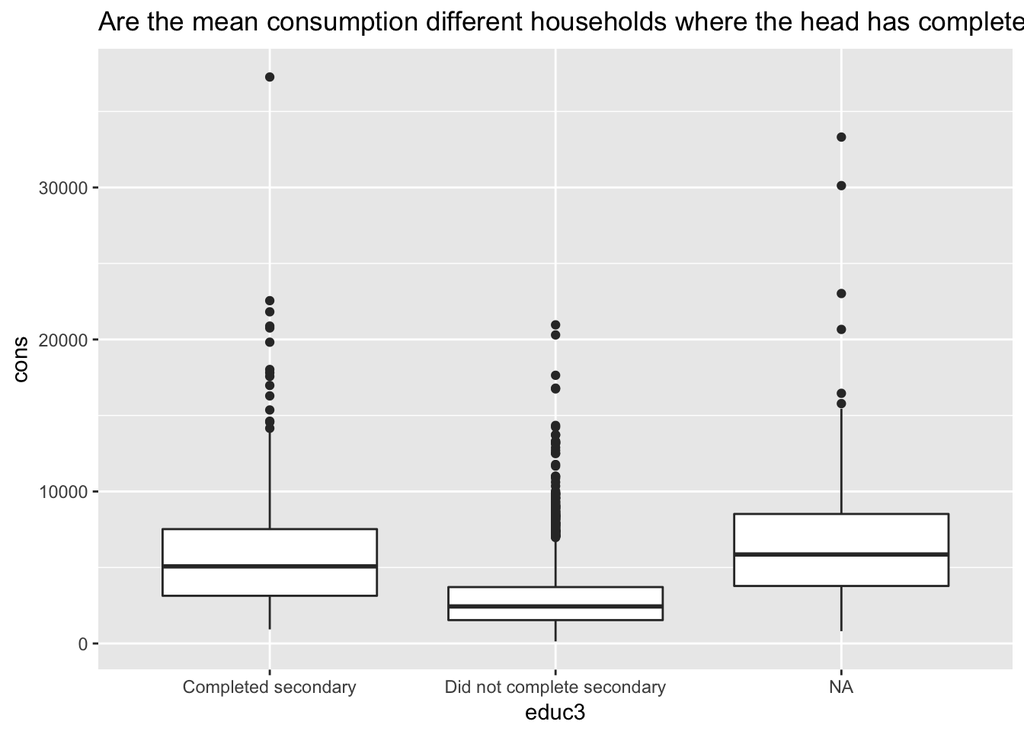

```r
library(ggplot2)

indiv = alldata[alldata$indidy4==1,]
p <- ggplot(indiv, aes(educ3, cons))

p + geom_boxplot() + labs(title="Are the mean consumption different households where the head has completed secondary level education?")
```

Let’s compare the means of consumption by subpopulation. Frequency table of consumption by gender and education level of head of houshold

```r
tapply(alldata$expmR, list(gender=alldata$gender,education=alldata$educ3), mean)
```

```
##       education
## gender Completed secondary Did not complete secondary
##      0             7114501                    4002123
##      1             6070763                    3063784
```

### PART 4. AGGREGATE TO REGION LEVEL

Based on our previous univariate analysis of consumption, we want to use the median consumption level of households by region

```r
exp=aggregate(cbind(cons) ~ region, data=alldata, FUN=median)
```

Use the mean of education (whether or not they completed secondary level education) and gender of head of household to get proportion of household heads that are female and proportion of household heads who completed a secondary level education by region

```r
ed=aggregate(cbind(educ2, gender) ~ region, data=alldata, FUN=mean)
```

Now we can merge the two data frames

```r
merge2=merge(ed, exp)

str(merge2)
```

```
## 'data.frame':    30 obs. of  4 variables:
##  $ region: num  1 2 3 4 5 6 7 8 9 10 ...
##  $ educ2 : num  0.1014 0.0941 0.0909 0.0568 0.129 ...
##  $ gender: num  0.275 0.306 0.421 0.261 0.301 ...
##  $ cons  : num  2007 2797 3437 2626 3283 ...
```

### Part 5. CORRELATIONS

Examine correlations between the three key variables

```r
res <- cor(merge2[,c(2:4)],use='complete.obs')
round(res, 2)
```

```
##        educ2 gender cons
## educ2   1.00  -0.14 0.57
## gender -0.14   1.00 0.13
## cons    0.57   0.13 1.00
```

Visualize correlation with scatterplots

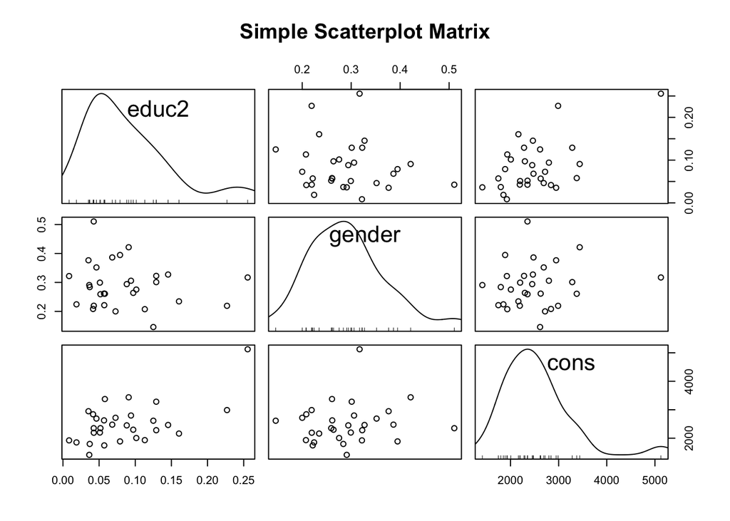

```r
library(car)
scatterplotMatrix(merge2[,c(2:4)],
   main="Simple Scatterplot Matrix",smoother = F,reg.line = F)
```

### PART 6 CLUSTERING

Make sure that the unit to be clustered is unique

```r
length(merge2$region)==length(unique(merge2$region))
```

```
## [1] TRUE
```

designate region (the unit of clustering) as row names

```r
row.names(merge2)=merge2$region
```

check variable type

```r
str(merge2[,c(2:4)])
```

```
## 'data.frame':    30 obs. of  3 variables:
##  $ educ2 : num  0.1014 0.0941 0.0909 0.0568 0.129 ...
##  $ gender: num  0.275 0.306 0.421 0.261 0.301 ...
##  $ cons  : num  2007 2797 3437 2626 3283 ...
```

Produce similarity matrix. We use euclidean method because all our variables are numerical

```r
library(cluster)

cluster=daisy(merge2[,c(2:4)],metric = "euclidean",
               stand=TRUE)
```

Apply clustering technique using similarity matrix we just created

```r
cluster1=hclust(cluster,method='complete')
```

Plot the clusters so we can compare the number of clusters visually

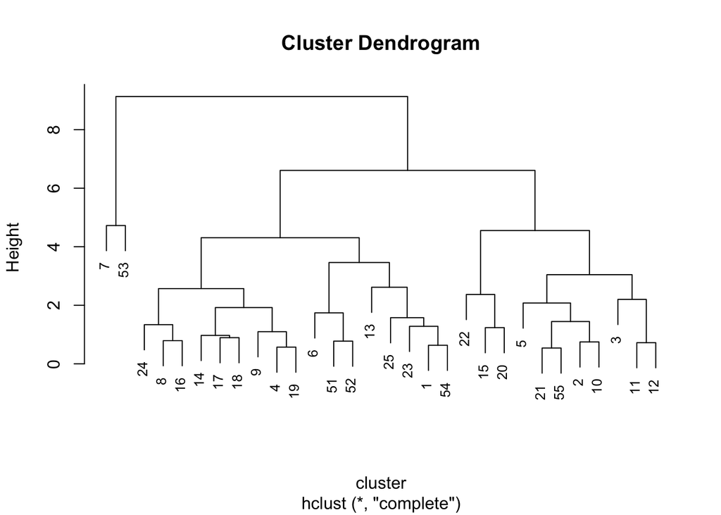

```r
plot(cluster1,cex=.8) #note: cex is a number indicating size of text and symbols in our plot
```

Let’s see what it looks like with 4 categories…

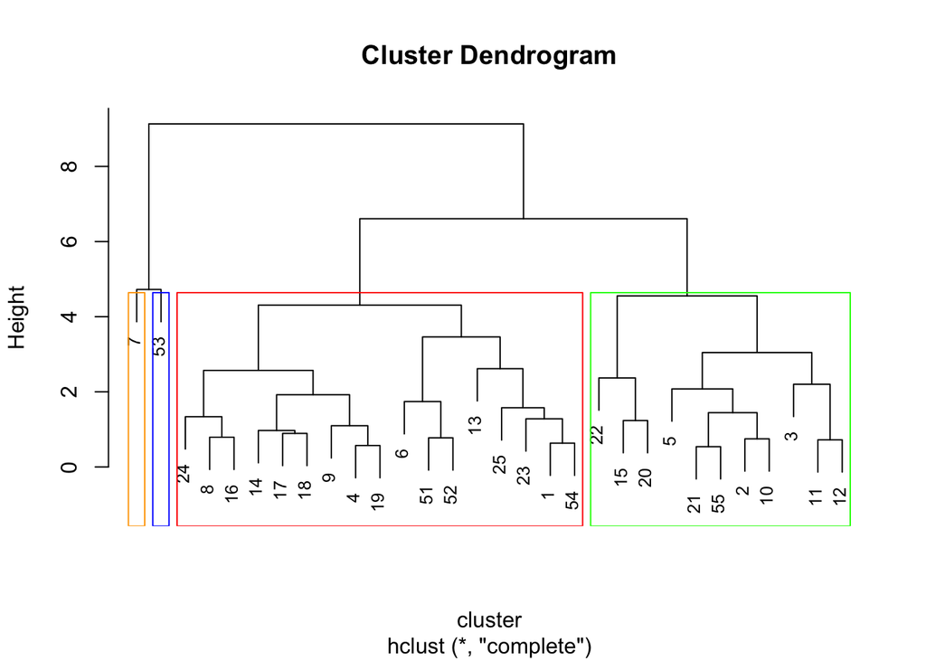

```r
plot(cluster1,cex=.8)
rect.hclust(cluster1, k = 4, border = c('orange', 'blue', 'red', 'green'))
```

How about 3?

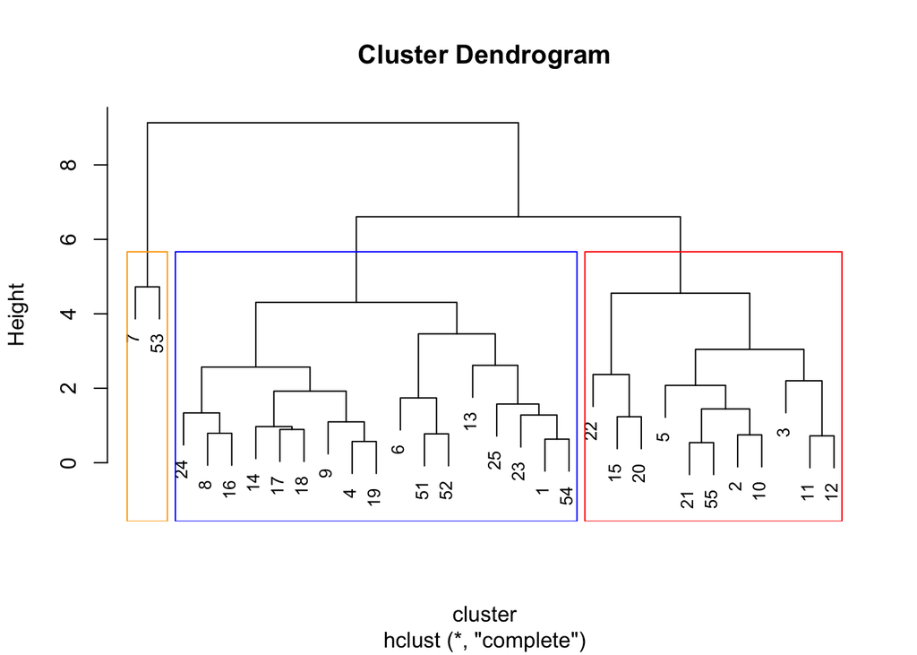

```r
plot(cluster1,cex=.8)
rect.hclust(cluster1, k = 3, border = c('orange', 'blue', 'red'))
```

We can also compare the different clustering numerically 4 groups

```r
demsil4=silhouette(cutree(cluster1, k = 4), cluster)
clust4solution=data.frame(matrix(demsil4,ncol = 3,dimnames =dimnames(demsil4)))
row.names(clust4solution)=merge2$region
(bad4=clust4solution[clust4solution$sil_width<0,])
```

```
##    cluster neighbor   sil_width
## 6        1        2 -0.00915535
## 10       2        1 -0.10115608
## 25       1        4 -0.13198040
```

3 groups

```r
demsil3=silhouette(cutree(cluster1, k = 3), cluster)
clust3solution=data.frame(matrix(demsil3,ncol = 3,dimnames =dimnames(demsil3)))
row.names(clust3solution)=merge2$region

(bad3=clust3solution[clust3solution$sil_width<0,])
```

```
##    cluster neighbor   sil_width
## 6        1        2 -0.00915535
## 10       2        1 -0.10115608
## 53       3        1 -0.10710242
```

What units of analysis are difficult to cluster?

```r
intersect(row.names(bad4), row.names(bad3))
```

```
## [1] "6"  "10"
```

Save our chosen clustering level, 3

```r
cluster3=clust3solution
```

Add a new column for region names

```r
cluster3$region=row.names(clust3solution)
row.names(cluster3)=NULL
```

Label our cluster levels

```r
cluster3$cluster.label[cluster3$cluster==1] <- "least developed"
cluster3$cluster.label[cluster3$cluster==2] <- "less developed"
cluster3$cluster.label[cluster3$cluster==3] <- "more developed"

str(cluster3)
```

```
## 'data.frame':    30 obs. of  5 variables:
##  $ cluster      : num  1 2 2 1 2 1 3 1 1 2 ...
##  $ neighbor     : num  2 1 1 2 1 2 2 2 2 1 ...
##  $ sil_width    : num  0.239 0.154 0.381 0.267 0.179 ...
##  $ region       : chr  "1" "2" "3" "4" ...
##  $ cluster.label: chr  "least developed" "less developed" "less developed" "least developed" ...
```

Merge our clustered variable with other variables into a new data frame

```r
merge3=merge(merge2, cluster3)

str(merge3)
```

```
## 'data.frame':    30 obs. of  8 variables:
##  $ region       : num  1 2 3 4 5 6 7 8 9 10 ...
##  $ educ2        : num  0.1014 0.0941 0.0909 0.0568 0.129 ...
##  $ gender       : num  0.275 0.306 0.421 0.261 0.301 ...
##  $ cons         : num  2007 2797 3437 2626 3283 ...
##  $ cluster      : num  1 2 2 1 2 1 3 1 1 2 ...
##  $ neighbor     : num  2 1 1 2 1 2 2 2 2 1 ...
##  $ sil_width    : num  0.239 0.154 0.381 0.267 0.179 ...
##  $ cluster.label: chr  "least developed" "less developed" "less developed" "least developed" ...
```

### PART 7 MAPPING

Source of geo data : http://gadm.org/country

#### Section 7.1 Merging geo data and other data

Designate location of shapefile

```r
compressedMap= "https://github.com/ihsun-uw/PROJECT/raw/master/Shapefile/TZA_adm_shp.zip"
```

Download and decompress zip file

```r
library(utils)
temp=tempfile()
download.file(compressedMap, temp)
unzip(temp)
```

Look at shapefiles

```r
(maps=list.files(pattern = 'shp'))
```

```
## [1] "TZA_adm0.shp" "TZA_adm1.shp" "TZA_adm2.shp" "TZA_adm3.shp"
```

Use admin level 1, which shows the regions of Tanzania

```r
library(rgdal)
TZmap <- rgdal::readOGR("TZA_adm1.shp",stringsAsFactors=F)
```

Look at variable names

```r
names(TZmap)
```

```
##  [1] "ID_0"      "ISO"       "NAME_0"    "ID_1"      "NAME_1"
##  [6] "HASC_1"    "CCN_1"     "CCA_1"     "TYPE_1"    "ENGTYPE_1"
## [11] "NL_NAME_1" "VARNAME_1"
```

Region name is variable NAME_1

```r
str(TZmap$NAME_1)
```

```
##  chr [1:30] "Arusha" "Dar es Salaam" "Dodoma" "Geita" "Iringa" ...
```

```r
TZmap$NAME_1
```

```
##  [1] "Arusha"                     "Dar es Salaam"
##  [3] "Dodoma"                     "Geita"
##  [5] "Iringa"                     "Kagera"
##  [7] "Katavi"                     "Kigoma"
##  [9] "Kilimanjaro"                "Lindi"
## [11] "Manyara"                    "Mara"
## [13] "Mbeya"                      "Morogoro"
## [15] "Mtwara"                     "Mwanza"
## [17] "Njombe"                     "Pemba North"
## [19] "Pemba South"                "Pwani"
## [21] "Rukwa"                      "Ruvuma"
## [23] "Shinyanga"                  "Simiyu"
## [25] "Singida"                    "Tabora"
## [27] "Tanga"                      "Zanzibar North"
## [29] "Zanzibar South and Central" "Zanzibar West"
```

Regions in our data are coded with numbers. Need to recode region names to match shapefile

```r
merge3$region.name[merge3$region==1] <-"Dodoma"
merge3$region.name[merge3$region==2] <-"Arusha"
merge3$region.name[merge3$region==3] <-"Kilimanjaro"
merge3$region.name[merge3$region==4] <-"Tanga"
merge3$region.name[merge3$region==5] <-"Morogoro"
merge3$region.name[merge3$region==6] <-"Pwani"
merge3$region.name[merge3$region==7] <-"Dar es Salaam"
merge3$region.name[merge3$region==8] <-"Lindi"
merge3$region.name[merge3$region==9] <-"Mtwara"
merge3$region.name[merge3$region==10] <-"Ruvuma"
merge3$region.name[merge3$region==11] <-"Iringa"
merge3$region.name[merge3$region==12] <-"Mbeya"
merge3$region.name[merge3$region==13] <-"Singida"
merge3$region.name[merge3$region==14] <-"Tabora"
merge3$region.name[merge3$region==15] <-"Rukwa"
merge3$region.name[merge3$region==16] <-"Kigoma"
merge3$region.name[merge3$region==17] <-"Shinyanga"
merge3$region.name[merge3$region==18] <-"Kagera"
merge3$region.name[merge3$region==19] <-"Mwanza"
merge3$region.name[merge3$region==20] <-"Mara"
merge3$region.name[merge3$region==21] <-"Manyara"
merge3$region.name[merge3$region==22] <-"Njombe"
merge3$region.name[merge3$region==23] <-"Katavi"
merge3$region.name[merge3$region==24] <-"Simiyu"
merge3$region.name[merge3$region==25] <-"Geita"
merge3$region.name[merge3$region==51] <-"Zanzibar North"
merge3$region.name[merge3$region==52] <-"Zanzibar South and Central"
merge3$region.name[merge3$region==53] <-"Zanzibar West"
merge3$region.name[merge3$region==54] <-"Pemba North"
merge3$region.name[merge3$region==55] <-"Pemba South"
```

Merge map and data files

```r
TZregmap=merge(TZmap, merge3, by.x='NAME_1', by.y='region.name', all.x=F)
```

Checking number of rows in shapefile and our data to see if we’re missing anything

```r
nrow(TZmap)
```

```
## [1] 30
```

```r
nrow(merge3)
```

```
## [1] 30
```

#### Section 7.2 Plotting on map

Install necessary packages to manage color and divisions

```r
library(RColorBrewer)
library(classInt)
```

Define which variable to plot (consumption)

```r
varToPLot=TZregmap$cons
```

Designate the number of intervals and colors for the map

```r
numberOfClasses = 8
colorForScale='YlGnBu'
colors = brewer.pal(numberOfClasses, colorForScale)
intervals <- classIntervals(varToPLot, numberOfClasses,
                            style = "quantile",
                            dataPrecision=2)
colorPallette <- findColours(intervals, colors)
```

Map consumption by region

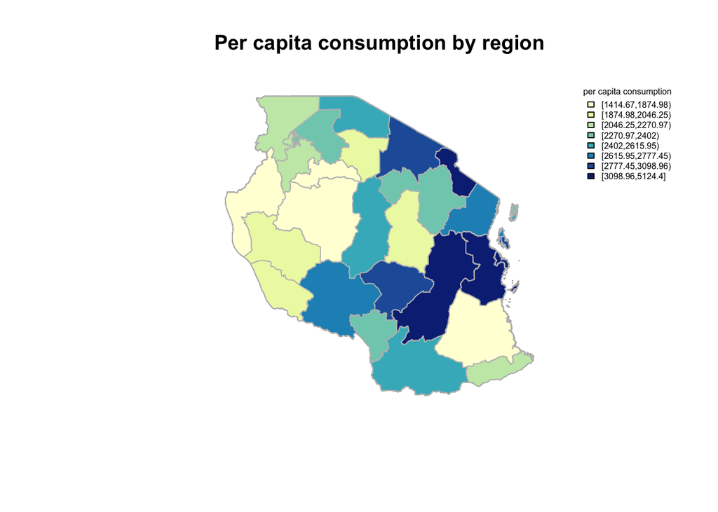

```r
legendText="per capita consumption"
shrinkLegend=0.5
title="Per capita consumption by region"

plot(TZmap,col='red',main=title)
plot(TZregmap, col = colorPallette,border='grey',add=T)

legend('topright', legend = names(attr(colorPallette, "table")),
       fill = attr(colorPallette, "palette"), cex = shrinkLegend,
       bty = "n",
       title=legendText)
```

Define second variable (education)

```r
varToPLot2=TZregmap$educ2
```

Repeat same step as above (designate colors and intervals)

```r
numberOfClasses = 8
colorForScale='YlGnBu'
colors = brewer.pal(numberOfClasses, colorForScale)
intervals <- classIntervals(varToPLot2, numberOfClasses,
                            style = "quantile",
                            dataPrecision=2)
colorPallette <- findColours(intervals, colors)
```

Map education by region

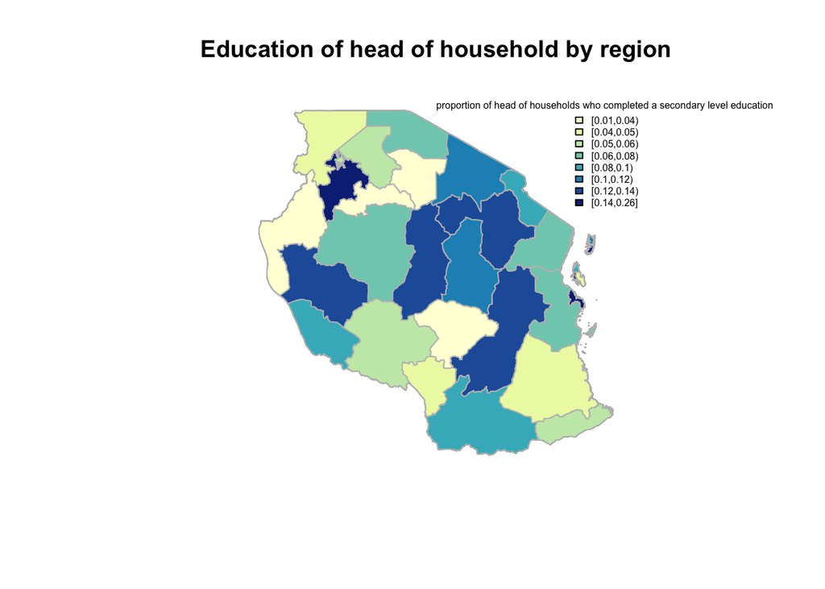

```r
legendText="proportion of head of households who completed a secondary level education"
shrinkLegend=0.5
title="Education of head of household by region"

plot(TZmap,col='red',main=title)
plot(TZregmap, col = colorPallette,border='grey',add=T)

legend('topright', legend = names(attr(colorPallette, "table")),
       fill = attr(colorPallette, "palette"), cex = shrinkLegend,
       bty = "n",
       title=legendText)
```

Define third variable (gender of head of household)

```r
varToPLot3=TZregmap$gender
```

Map gender

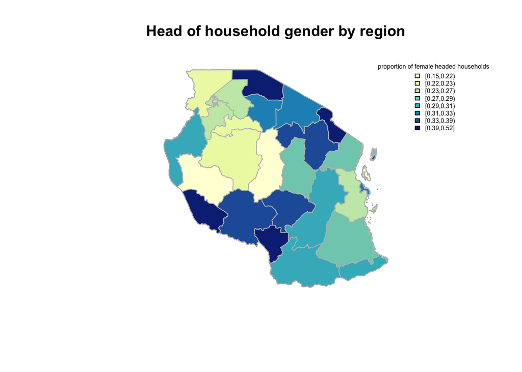

```r
numberOfClasses = 8
colorForScale='YlGnBu'
colors = brewer.pal(numberOfClasses, colorForScale)
intervals <- classIntervals(varToPLot3, numberOfClasses,
                            style = "quantile",
                            dataPrecision=2)
colorPallette <- findColours(intervals, colors)

legendText="proportion of female headed households"
shrinkLegend=0.5
title="Head of household gender by region"

plot(TZmap,col='red',main=title)
plot(TZregmap, col = colorPallette,border='grey',add=T)

legend('topright', legend = names(attr(colorPallette, "table")),
       fill = attr(colorPallette, "palette"), cex = shrinkLegend,
       bty = "n",
       title=legendText)
```

Define fourth variable- our clustered variable. First we need to define the variable as a factor because it is not a numerical variable. It is categorical.

```r
TZregmap$cluster=factor(TZregmap$cluster)
```

Now we can define the variable for mapping

```r
varToPlot4=TZregmap$cluster
```

Define the number of classes as the number of groups in the cluster variable. Set color.

```r
numberOfClasses = length(levels(varToPlot4))
colorForScale='Set2'
colors = brewer.pal(numberOfClasses, colorForScale)
```

Map cluster by region

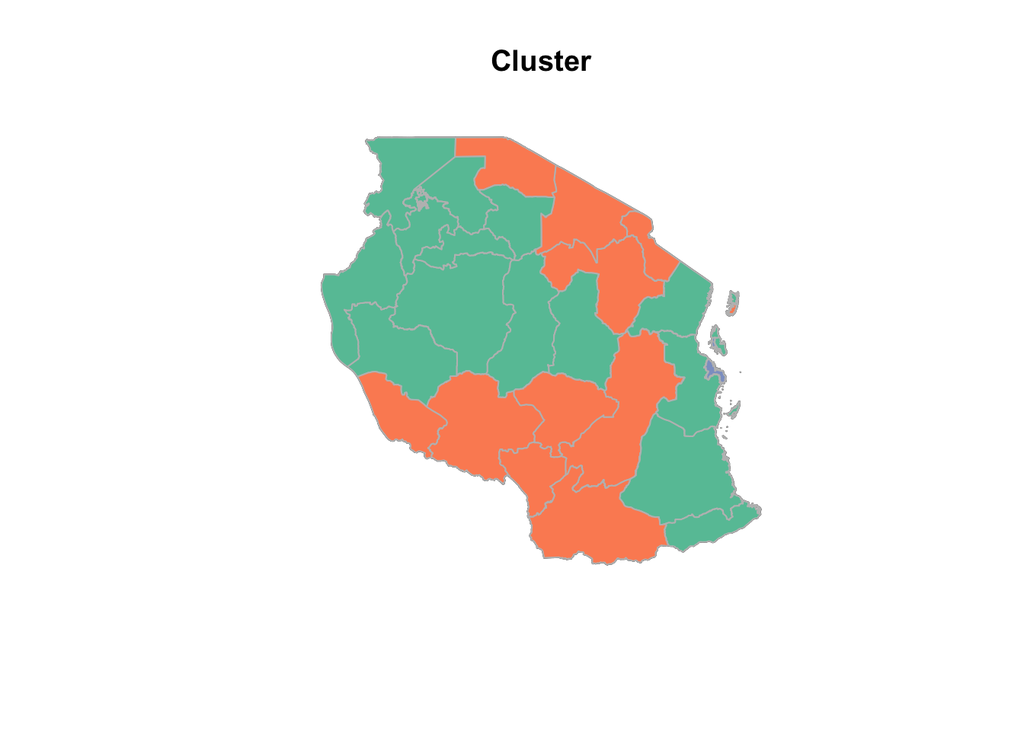

```r
title="Cluster"

plot(TZmap,col='black',main=title)
plot(TZregmap, col = colors[varToPlot4],border='grey',add=T)
```